# drugi_zadatak

Luka

2025-01-25

# 3.2. Postoji li razlika u prvoj ocjeni iz matematike s obzirom na mjesto stanovanja učenika?

## Pregled podataka

Prije samog odgovora na postavljeno pitanje, provjerimo prvo podatkovni skup te koje bi nam značajke bile važne za pronalazak odgovora.

```r
student_data <- read.csv('student_data.csv')
head(student_data, 3)
```

```
##   school sex age address famsize Pstatus Medu Fedu    Mjob    Fjob reason
## 1     GP   F  18       U     GT3       A    4    4 at_home teacher course
## 2     GP   F  17       U     GT3       T    1    1 at_home   other course
## 3     GP   F  15       U     LE3       T    1    1 at_home   other  other
##   guardian traveltime studytime failures_mat failures_por schoolsup famsup
## 1   mother          2         2            0            0       yes     no
## 2   father          1         2            0            0        no    yes
## 3   mother          1         2            3            0       yes     no
##   paid_mat paid_por activities nursery higher internet romantic famrel freetime
## 1       no       no         no     yes    yes       no       no      4        3
## 2       no       no         no      no    yes      yes       no      5        3
## 3      yes       no         no     yes    yes      yes       no      4        3
##   goout Dalc Walc health absences_mat absences_por G1_mat G2_mat G3_mat G1_por
## 1     4    1    1      3            6            4      5      6      6      0
## 2     3    1    1      3            4            2      5      5      6      9
## 3     2    2    3      3           10            6      7      8     10     12
##   G2_por G3_por
## 1     11     11
## 2     11     11
## 3     13     12
```

U skupu podataka možemo vidjeti da ‘G1_mat’ varijabla predstavlja prvu ocjenu iz matematike (cjelobrojna vrijednost u rasponu od 0 - 20), te pomoću ‘address’ varijable doznajemo studentovo mjesto stanovanja (U - urban/grad, R - rural/selo). Te ćemo varijable izdvojiti iz skupa podataka za daljnju statističku analizu i testiranja.

```r
columns <- c('G1_mat', 'address')
grades <- student_data[columns]
```

## Vizualizacija

Sada ćemo iskoristiti metodu vizualizacije da provjerimo ovisnost prve ocjene iz matematike s obzirom na mjesto stanovanja pomoću box plot-a.

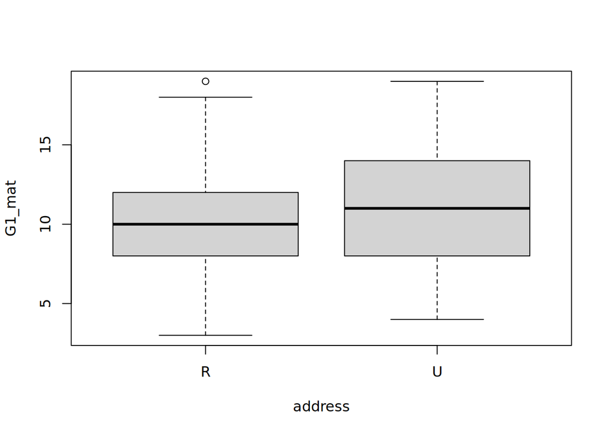

```r
grades$address <- factor(grades$address)

plot(G1_mat ~ address, grades)
```

Uz pomoć našeg box plot-a ne možemo dobiti empirijski odgovor na postavljeno pitanje, no možemo očekivati da neće biti razlike u prvoj ocjeni iz matematike s obzirom na mjesto stanovanja. Kako bismo to statistički zaključili, moramo provesti neki od testova za usporedbu sredina uzoraka poput t testa, za čije izvođenje uzimamo pretpostavku normalnosti podataka.

Provjerimo normalnost podataka koristeći histograme i qq plotove.

```r
rural_scores = subset(grades, address == 'R')$G1_mat
urban_scores = subset(grades, address == 'U')$G1_mat
```

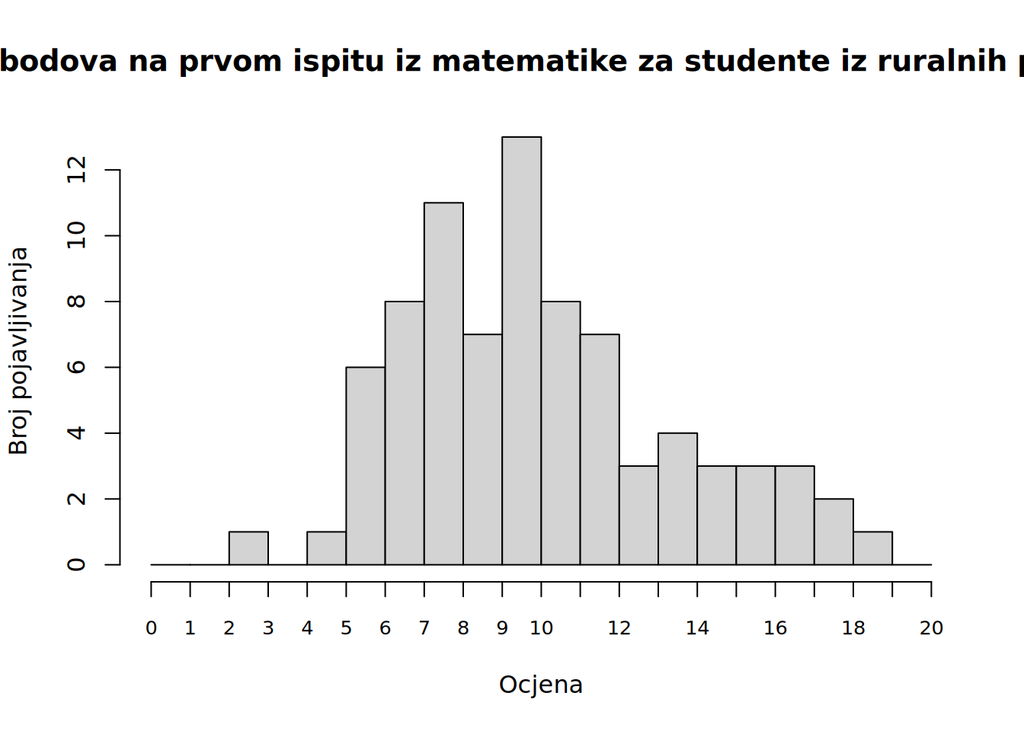

```r
hist(rural_scores, breaks=seq(0, 20, by=1), xaxt = "n", main='Broj bodova na prvom ispitu iz matematike za studente iz ruralnih podrucja', xlab='Ocjena', ylab='Broj pojavljivanja')
axis(1, at=seq(0, 20, by=1), labels=seq(0, 20, by=1), cex.axis=0.8)
```

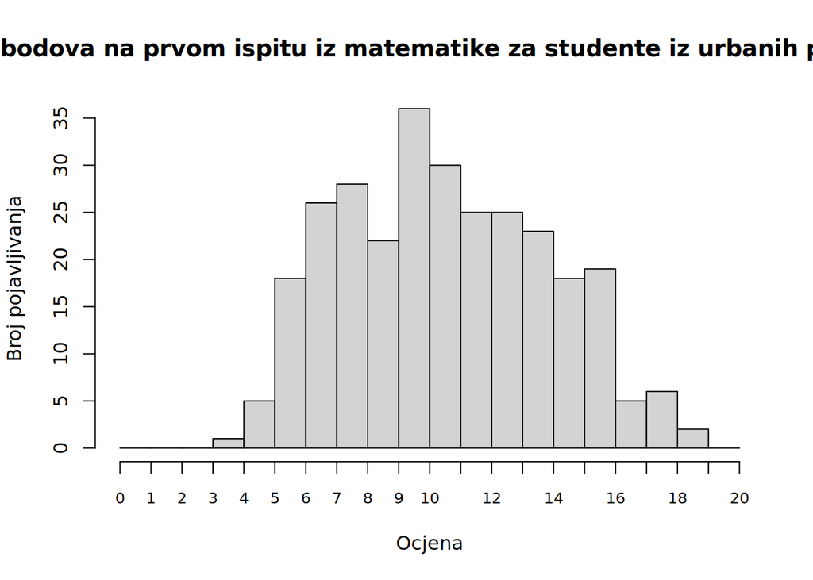

```r
hist(urban_scores, breaks=seq(0, 20, by=1), xaxt = "n", main='Broj bodova na prvom ispitu iz matematike za studente iz urbanih podrucja', xlab='Ocjena', ylab='Broj pojavljivanja')
axis(1, at=seq(0, 20, by=1), labels=seq(0, 20, by=1), cex.axis=0.8)
```

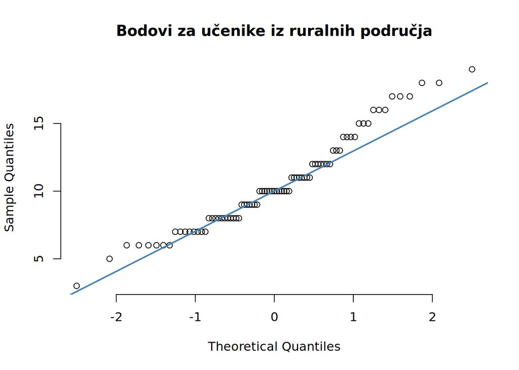

```r
qqnorm(rural_scores, pch = 1, frame = FALSE,main='Bodovi za učenike iz ruralnih područja')
qqline(rural_scores, col = "steelblue", lwd = 2)
```

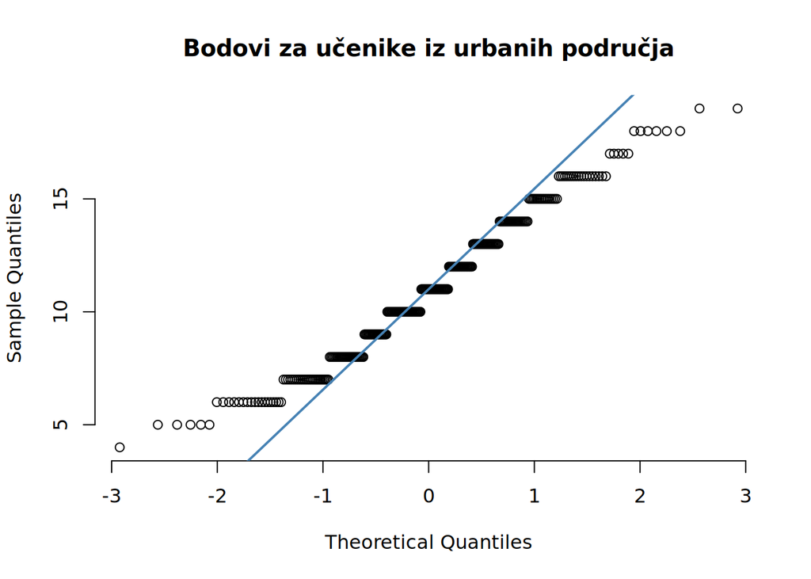

```r
qqnorm(urban_scores, pch = 1, frame = FALSE,main='Bodovi za učenike iz urbanih područja')
qqline(urban_scores, col = "steelblue", lwd = 2)
```

Pretpostavke ANOVA-e su:

- nezavisnost pojedinih podataka u uzorcima,
- normalna razdioba podataka,
- homogenost varijanci među populacijama.

Kad su veličine grupa podjednake, ANOVA je relativno robusna metoda na blaga odstupanja od pretpostavke normalnosti i homogenosti varijanci. Ipak, dobro je provjeriti koliko su ta odstupanja velika.

Provjera normalnosti može se za svaku pojedinu grupu napraviti KS testom ili Lillieforsovom inačicom KS testa.

H0: podaci su normalno distribuirani  
H1: podaci nisu normalno distribuirani  
alpha = 0.05

```r
lillie.test(rural_scores)
```

```
##
##  Lilliefors (Kolmogorov-Smirnov) normality test
##
## data:  rural_scores
## D = 0.13319, p-value = 0.001155
```

```r
lillie.test(urban_scores)
```

```
##
##  Lilliefors (Kolmogorov-Smirnov) normality test
##
## data:  urban_scores
## D = 0.090667, p-value = 5.345e-06
```

Što se tiče homogenosti varijanci različitih populacija, potrebno je testirati:
$$\begin{aligned}
H_0 & : \sigma_1^2 = \sigma_2^2 = \ldots = \sigma_k^2 \\
H_1 & : \text{barem dvije varijance nisu iste}.
\end{aligned}$$
Navedenu hipotezu možemo testirati Bartlettovim testom. Bartlettov test u R-u implementiran je naredbom `bartlett.test()`.

```r
# Testiranje homogenosti varijance uzoraka Bartlettovim testom

bartlett.test(G1_mat ~ address, grades)
```

```
##
##  Bartlett test of homogeneity of variances
##
## data:  G1_mat by address
## Bartlett's K-squared = 0.14685, df = 1, p-value = 0.7016
```

Varijance su homogene što nam omogućuje provođenje Anove.

```r
# Test
a = aov(G1_mat ~ address, grades)
summary(a)
```

```
##              Df Sum Sq Mean Sq F value Pr(>F)
## address       1     20   19.63   1.758  0.186
## Residuals   368   4110   11.17
```

p-vrijednost je 0.186 -> ne možemo odbaciti H0

t-test

```r
t.test(rural_scores, urban_scores, var.equal = TRUE)
```

```
##
##  Two Sample t-test
##
## data:  rural_scores and urban_scores
## t = -1.3258, df = 368, p-value = 0.1857
## alternative hypothesis: true difference in means is not equal to 0
## 95 percent confidence interval:
##  -1.3832551  0.2691537
## sample estimates:
## mean of x mean of y
##  10.45679  11.01384
```

Zaključujemo da ne postoji razlika u prvoj ocjeni iz matematike s obzirom na mjesto stanovanja učenika.